# esm206-lab6-ac

Annie Combs

November 1, 2021

## Example of a rank-based test

We'll make our own samples using a pseudorandom generator

```r
set.seed(1414)
gp_1 <- sample.int(20, size = 15, replace = TRUE)

set.seed(1424)
gp_2 <- sample.int(30, size = 15, replace = TRUE)
```

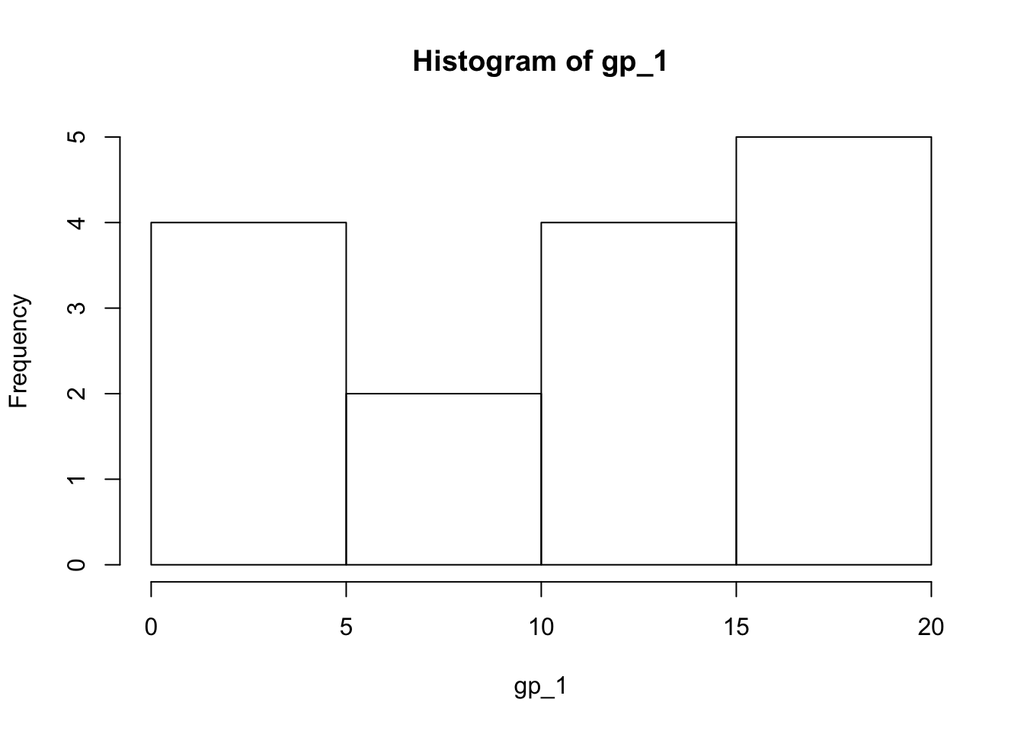

```r
hist(gp_1)
```

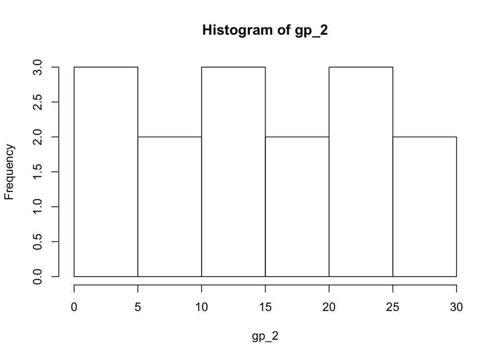

```r
hist(gp_2)
```

Try a t test

```r
t.test(gp_1, gp_2)
```

```
##
##  Welch Two Sample t-test
##
## data:  gp_1 and gp_2
## t = -1.3241, df = 23.545, p-value = 0.1982
## alternative hypothesis: true difference in means is not equal to 0
## 95 percent confidence interval:
##  -9.558315  2.091648
## sample estimates:
## mean of x mean of y
##  11.40000  15.13333
```

The p value means that there is a 19.8% chance that the sample means are at least this different by random chance, assuming that these two samples come from populations with the same mean.

We will fail to reject (retain) the null hypothesis. >> there is no significant difference in means between group 1 and group 2 (say that on final)

Warning: people get weirdly upset if you say "accept the null". If accept or reject the null comes up in your final, you will LOSE POINTS.

Compare this outcome to a rank-based test.

## Mann Whitney U unpaired rank based test

```r
mwu <- wilcox.test(gp_1, gp_2)
```

```
## Warning in wilcox.test.default(gp_1, gp_2): cannot compute exact p-value with
## ties
```

```r
mwu
```

```
##
##  Wilcoxon rank sum test with continuity correction
##
## data:  gp_1 and gp_2
## W = 86, p-value = 0.28
## alternative hypothesis: true location shift is not equal to 0
```

```r
# ?wilcox.test in console to check values
# mwu$p.value (or other value) into console to pull individually
```

p value means that there is a 28% chance that your sample ranks will be at least this different assuming that your samples came from populations with the same ranks (median).

No significant difference in ranks/medians between group 1 and group 2.

Median Scores for group 1: (M = 14) and group 2 (M = 12) did not differ significantly (Mann Whitney U test: U(df) = 86, p = 0.28).

## Linear Regression

Simple linear regression (single dependent variable and a single independent variable)

Find a linear regression model using ordinary least squares describing the relationsip between flipper length and body mass for these penguins

3 pieces: type of model what is the relationship to model (DV ~ IV(s)) where is the data that is used to create this model

```r
penguin_lm <- lm(body_mass_g ~ flipper_length_mm, data = penguins)
```

y = mx + b

y = beta 1 + beta 0 + error

x/B1 = flipper length y = body mass

body mass = 49.7 * (flipper length) - 5780.83 g (y intercept)

For every 1 mm increase in flipper length, I expect a 49.7 gram increase in body mass.

units for 49.7 g/mm

If flipper length is 0, this model predicts that its body mass would be -5780.83 g which is impossible. All models are wrong adn extrapolation is risky.

How would I actually look at the values? console: penguin_lm$coefficients single element in console: penguin_lm$coefficients[2]

### broom package returns model outputs as tidy data frames

```r
penguin_lm_tidy <- broom::tidy(penguin_lm)

penguin_lm_tidy
```

```
## # A tibble: 2 × 5
##   term              estimate std.error statistic   p.value
##   <chr>                <dbl>     <dbl>     <dbl>     <dbl>
## 1 (Intercept)        -5781.     306.       -18.9 5.59e- 55
## 2 flipper_length_mm     49.7      1.52      32.7 4.37e-107
```

```r
broom::glance(penguin_lm) # model-wide indicators of fit and uncertainty
```

```
## # A tibble: 1 × 12
##   r.squared adj.r.squared sigma statistic   p.value    df logLik   AIC   BIC
##       <dbl>         <dbl> <dbl>     <dbl>     <dbl> <dbl>  <dbl> <dbl> <dbl>
## 1     0.759         0.758  394.     1071. 4.37e-107     1 -2528. 5063. 5074.
## # … with 3 more variables: deviance <dbl>, df.residual <int>, nobs <int>
```

How can I actually include my model equation in a report?

```r
extract_eq(model = penguin_lm, use_coefs = TRUE) # stores a version of the outcomes from that model that looks awesome when you knit
```

$$\operatorname{\widehat{body\_mass\_g}} = -5780.83 + 49.69(\operatorname{flipper\_length\_mm})$$